```python
# %matplotlib notebook
import numpy
import scipy.integrate
import matplotlib.pyplot as plt
import numpy as np
import matplotlib.animation as animation
```

# Chaotic dynamics

Recall that a classical *state* is the conjugate pair $(q_i, p_i)$. The space of states is the phase space of the system. Before we discuss chaos, let's visualize how states evolve in the absence of chaos. Consider the SHO with Hamiltonian $$ H_{SHO} = \frac{p^2}{2m}+\frac{1}{2}kx^2 $$ which has a two dimensional phase space. The Hamilton equations of motion are $$ \dot x= \frac{p}{m} \quad \dot p = -kx $$ Let us simulate this

```python
def SHO_kernel(states, t):
    x, p = states
    return [p, -x]

def quartic_kernel(states, t):
    x, p = states
    return [p, x-x**3]
```

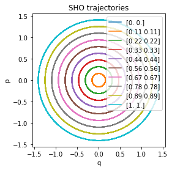

```python
solver = lambda kernel, u0, t: scipy.integrate.odeint(kernel, u0, t, atol=1e-10, rtol=1e-11)
def trajectories(kernel, initial_conditions):
    t = np.linspace(0, 100, 1000)
    result = solver(kernel, initial_conditions, t)
    x, p = result.T
    plt.plot(x, p, label=str(np.round(initial_conditions, 2)))
    plt.axis('image')
    plt.xlabel("q")
    plt.ylabel("p")
    # plt.axis([-3, 3, -3, 3])

plt.figure()
plt.title("SHO trajectories")
for init_x, init_p in zip(np.linspace(0, 1, 10), np.linspace(0, 1, 10)):
    trajectories(SHO_kernel, [init_x, init_p])
plt.legend();
```

Nonlinearity is necessary for chaos but not sufficient. In fact, sufficient conditions for the development of chaos has not been determined in any generality. Take a look at the quartic oscillator with Hamiltonian $$ H = \frac{p^2}{2m} -\frac{1}{2}kx^2 + \frac{1}{4}x^4 $$ with EOMs $$ \dot x= \frac{p}{m} \quad \dot p = kx- x^3$$

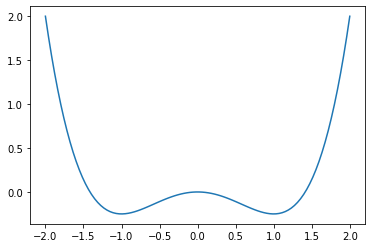

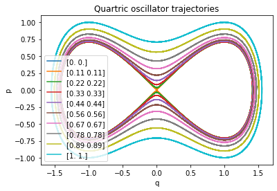

```python
x = np.linspace(-2, 2, 100)
plt.figure()
plt.plot(x, -x**2/2+x**4/4)
plt.figure()
plt.title("Quartric oscillator trajectories")
for init_x, init_p in zip(np.linspace(0, 1, 10), np.linspace(0, 1, 10)):
    trajectories(quartic_kernel, [init_x, init_p])
plt.legend();
```

Notice that the initial conditions are valued in densely in the box $[0,1]\times[0,1]$. Similarly, the trajectories are densely packed near one another. There is no chaos here.

## A chaotic phase trajectory

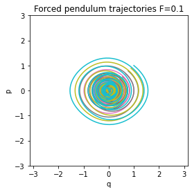

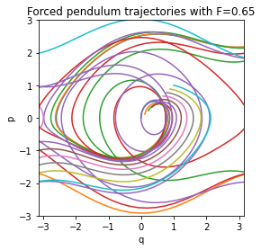

```python
from functools import partial
def forced_plane_pendulum_kernel(states, t, f0):
    x, p = states
    x = np.mod(x+np.pi,2*np.pi)-np.pi
    return [p, -0.05*p-np.sin(x)+f0*np.cos(0.7*t)]
plt.figure()
plt.title("Forced pendulum trajectories F=0.1")
for init_x, init_p in zip(np.linspace(0, 1, 10), np.linspace(0, 1, 10)):
    trajectories(partial(forced_plane_pendulum_kernel, f0=0.1), [init_x, init_p])
plt.axis([-np.pi, np.pi, -3, 3]);
plt.figure()
plt.title("Forced pendulum trajectories with F=0.65")
for init_x, init_p in zip(np.linspace(0, 1, 10), np.linspace(0, 1, 10)):
    trajectories(partial(forced_plane_pendulum_kernel, f0=0.65), [init_x, init_p])
plt.axis([-np.pi, np.pi, -3, 3]);
# plt.legend();
```

For $F=0.65$ the phase space trajectories are all over the place (even though they started very close together) which is not the case for $F=0.1$. We then have some confidence in declaring that the second plot is indicative of chaos. Can we make this more precise?

## Lyapunov criterion

A precise definition of chaos is due to Lyapunov:

> If two phase space trajectories that are initially $\epsilon$ separated, under chaotic time evolution, their separation diverges *on average*.

We can check this numerically by seeing if the difference between trajectories diverges or converges:

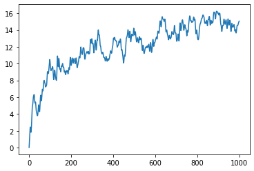

```python
epsilon = 0.01
d = []
for x0, p0 in zip(np.linspace(0, 1, 20), np.linspace(0, 1, 20)):
    result1 = solver(partial(forced_plane_pendulum_kernel, f0=0.4), [x0, p0], np.linspace(0,100, 1000))
    x1, p1 = result1.T
    result2 = solver(partial(forced_plane_pendulum_kernel, f0=0.4), [x0+epsilon, p0+epsilon], np.linspace(0,1000, 1000))
    x2, p2 = result2.T
    d.append(np.sqrt((x1-x2)**2+(p1-p2)**2))
d = np.array(d)
plt.plot(d.mean(axis=0))
```

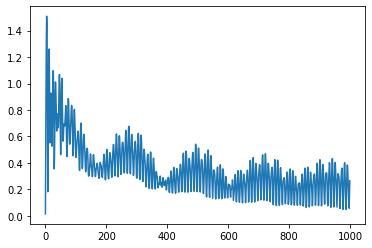

```python
epsilon = 0.01
d = []
for x0, p0 in zip(np.linspace(0, 1, 20), np.linspace(0, 1, 20)):
    result1 = solver(partial(forced_plane_pendulum_kernel, f0=0.1), [x0, p0], np.linspace(0,100, 1000))
    x1, p1 = result1.T
    result2 = solver(partial(forced_plane_pendulum_kernel, f0=0.1), [x0+epsilon, p0+epsilon], np.linspace(0,1000, 1000))
    x2, p2 = result2.T
    d.append(np.sqrt((x1-x2)**2+(p1-p2)**2))
d = np.array(d)
plt.plot(d.mean(axis=0))
```

## The Poincare map

Let $\gamma_p:[0, 1]\to \mathcal P$ be the trajectory in phase space, $\mathcal P$ passing through point $p$. Assume the trajectory to be periodic (clsoed curves in phase space). Define a Hamoltonian evolution function, $\varphi:\mathcal P\times \mathbb R\to\mathcal P$ through $e^{iHt}$. The Poincare map is the *section* of $\varphi$ through $p$. That is, a map $\sigma_P$ s.t. $\sigma\cdot \varphi\big\vert_p = \mathbb I_{\mathcal P}$. This is a differential geometric way of saying the following:

Take a bunch of copies of your phase space, and on them, represent by the point $(q_t, p_t)$ the state at time $t$. The state at time $t+\delta$ is represented on an adjacent copy of phase space. Then, once you've time evolved sufficiently many times, project all this data to a single phase space.

```python
pi = np.pi
def modified_pendulum(states, t, f0):
    states = np.mod(states+np.pi,2*np.pi)-np.pi
    omega, C = 0.7, 0.05
    x, p, z = states
    return [p, -C*p-np.sin(x)+f0*np.cos(z), omega]
# ref: https://stackoverflow.com/questions/53792164/how-to-implement-a-method-to-generate-poincar%C3%A9-sections-for-a-non-linear-system
def find_crosssections(kernel, x0, y0, t=np.arange(0, 1000, 0.2)):
    px, py = [], []
    result = solver(kernel, [x0,y0,0], t)
    result = np.mod(result+pi,2*pi)-pi
    x, y, z = result.T
    for k in range(len(z)-1):
        if z[k] <= 0 <= z[k + 1] and z[k + 1]-z[k]<pi:
            s = -z[k]/(z[k+1]-z[k])  # 0 = z[k] + s*(z[k+1]-z[k])
            rx, ry = (1-s)*x[k]+s*x[k+1], (1-s)*y[k]+s*y[k+1]
            px.append(rx);
            py.append(ry);
    return px,py

def plot_sections(kernel, N=20):
    plt.figure()
    grid = np.zeros([N,N], dtype=int)
    for i in range(N):
        for j in range(N):
            if grid[i,j]>0: continue;
            x0, y0 = (2*i+1)*np.pi/N-np.pi, (2*j+1)*np.pi/N-np.pi
            px, py = find_crosssections(kernel, x0,y0)
            for rx,ry in zip(px,py):
                m, n = int((rx+np.pi)*N/(2*np.pi)), int((ry+np.pi)*N/(2*np.pi))
                grid[m,n]=1
        plt.plot(px, py, '.', ms=2)
```

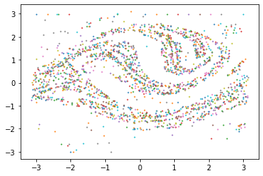

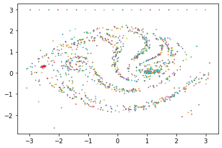

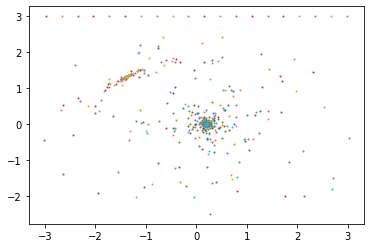

```python
plot_sections(partial(modified_pendulum, f0=0.7))
plot_sections(partial(modified_pendulum, f0=0.4))
plot_sections(partial(modified_pendulum, f0=0.1))
```

Qualitatively, if the Poincare sections *look interesting*, the system is chaotic.

## Discrete state mapping

A simpler, but actually more general idea is to describe discrete dynamics through the update equation $$ q_{n+1} = f(\alpha, q_n) $$ where $\alpha$ is a set of parameters. Since chaotic systems are only solvable numerically, the discretization is not really a loss of generality - assuming the future state only depends on the immediately preceding state is though.

Plotting $q_n$ as a function of the parameters $\alpha$ allows us to visually inspect the solution space. In general, there will be multiple solutions for a given $\alpha$ with different solutions exhibiting different stability properties. At least qualitatively, a very complex dependence on $\alpha$ after sufficiently many iterations is indicative of chaos.

Let's study this numerically for the logistic update equation: $$ x_{n+1} =\alpha x_n (1-x_n) $$ The idea is to simply build a solution by iterating forward in discrete time:

```python
logistic = lambda xn, alpha: alpha*xn*(1-xn)
def iterative_solver(update_function, alpha, N, x0=1):
    x = np.zeros(N)
    x[0] = x0
    for i in range(0, N-1):
        x[i+1] = update_function(x[i], alpha)
    return x[-1]
```

### Hard CS tangent

Let's introduce an alternative here: Notice that $x_N=f\circ \cdots\circ f(x_0)$ which we may denote as $x_N = f_N(x_0)$. Instead of an iterator, we can write a function composer to map $x_0\to x_N$. This is the idea behind functional programming (which python is not good at). In a functional programming language, function composition should be baked in to the language but, in the case of python, we have to define a rather obscure function that simply implements $f\circ g\circ ...$: `compose = lambda *F: reduce(lambda f, g: lambda x: f(g(x)), F)` Using this, we can write a solver in 1 line:

```python
compose = lambda *ff: reduce(lambda f, g: lambda x: f(g(x)), ff)
functional_solver = lambda f, N, x0: compose(*[partial(f, alpha=alpha)]*N)(x0)
```

### End tangent

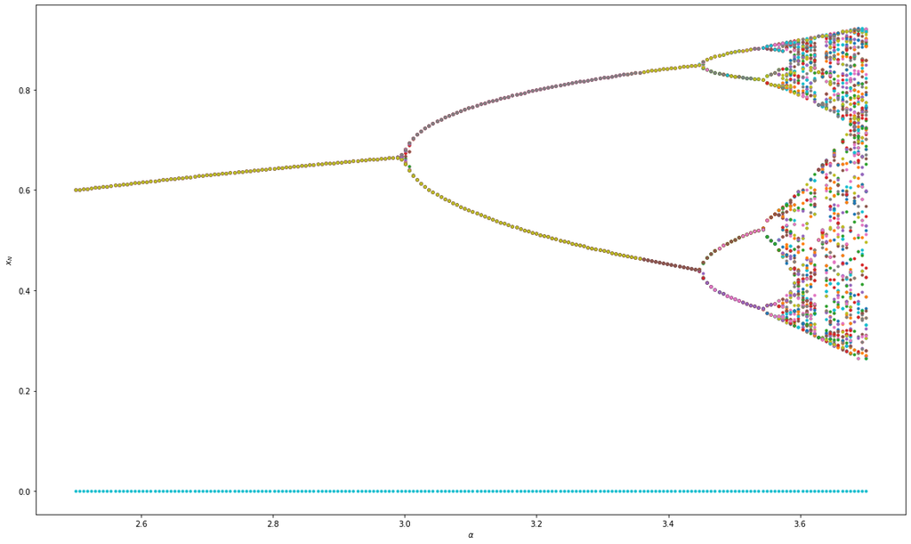

```python
alphas = np.linspace(2.5, 3.7, 200)
inits = np.linspace(0.1, 1, 100)
xN = np.zeros([len(inits), len(alphas)])
N = 300
for i, init in enumerate(inits):
    for j, alpha in enumerate(alphas):
        xN[i, j] = functional_solver(partial(logistic, alpha=alpha), N, x0=init)
        # xN[i, j] = iterative_solver(logistic, alpha, N, x0=init)
plt.figure(figsize=(20, 12))
plt.plot(alphas, xN.T, '.')
plt.xlabel(r'$\alpha$')
plt.ylabel(r'$x_{N}$');
```

### Lyapunov for update equations

When we have a discrete update equation, we have a stronger definition of chaos:

> If two phase space trajectories that are initially $\epsilon$ separated, under chaotic time evolution, their separation grows as $$ d_n = \epsilon e^{\lambda n}. $$ with $\lambda>0$ *on average* after $n$ iterations.

Here $d_n=f_n(q+\epsilon)-f_n(q)$ where $f_n$ denotes the $n$-th iterate of the update function. Then, the Lyapunov exponent is, asymptotically, the empirical mean $$ \lambda \sim_{n\to \infty} \frac{1}{n}\sum_i \ln\|f'(q_i)\| $$

- $λ =0 \implies$ bifurcation
- $\lambda>0\implies$ chaos
- $\lambda <0\implies$ not chaos

## Solution to discussion problem

We have the following update equation: $$ x_n = \alpha\sin(\pi x_{n-1})+\alpha^2 x_{n-1}(1-x_{n-1}) $$

[figure not shown]

```python
alphas = np.linspace(0.1, 1.5, 200)
inits = np.linspace(0.1, 1, 100)
xN = np.zeros([len(inits), len(alphas)])
N = 200
for i, init in enumerate(inits):
    for j, alpha in enumerate(alphas):
        xN[i, j] = iterative_solver(lambda xn, alpha: alpha*np.sin(xn*np.pi)+alpha**2*xn*(1-xn), alpha, N, x0=init)[-1]
plt.figure(figsize=(20, 12))
plt.plot(alphas, xN.T, '.')
plt.xlabel(r'$\alpha$')
plt.ylabel(r'$x_{N}$');
```